# ANTsRNet Reference

## Publications

1. Thomas Lin Pedersen. [Taking Control of Plot Scaling](https://www.tidyverse.org/blog/2020/08/taking-control-of-plot-scaling/).
   - [28.7 Saving your plots](https://r4ds.had.co.nz/graphics-for-communication.html#saving-your-plots) from [R for Data Science](https://r4ds.had.co.nz) by Garrett Grolemund and Hadley Wickham.
2. [D.1 Introduction](https://bookdown.org/hneth/ds4psy/D-1-apx-colors-intro.html) from the bookdown [Data Science for Psychologists](https://bookdown.org/hneth/ds4psy/) by Hansjörg Neth
3. [Non-standard evaluation](https://cran.r-project.org/web/packages/lazyeval/vignettes/lazyeval.html).

## Setup

```r
`%<-%` <- keras::`%<-%`
```

```r
library(tidyverse)
library(cowplot)
library(ANTsRCore)
library(ANTsRNet)
```

## Draw sample of data tensors/images

```r
names_5x5 <- names(make_arrays_5x5())
arrays_5x5 <- make_arrays_5x5()
```

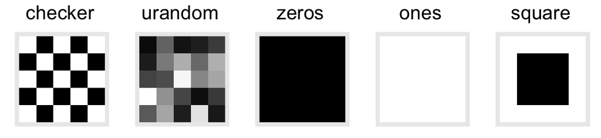

Use the sample tensors defined above to create several color images.

```r
c(checker, urandom, zeros, ones, square) %<-% make_arrays_5x5()

channels3 <- list(
  list(checker, 1 - checker, zeros),
  list(checker, 1 - checker, ones),
  list(checker, 1 - checker, square),
  list(checker, square, 1 - checker),
  list(zeros, zeros, checker),
  list(checker, urandom, 0.25 * ones)
)
```

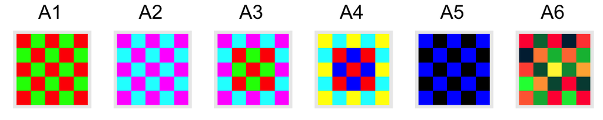

## ANTsRNet::encodeUnet

Encoding function for `groundTruthSegmentations` (`Y_train`) It uses the labels provided by `segmentationLabels` vector.

```r
encodeUnet(groundTruthSegmentations, segmentationLabels)
```

where `groundTruthSegmentations` (`Y_train`) is an array (tensor) of shape
$$\rm batch\ size \times width \times height$$

### Value

The value is an array of the shape
$$\rm batch\ size \times width \times height \times
\langle depth\rangle$$
where $\langle depth\rangle$ is equal to `length(segmentationLabels)`.

### Examples

First, we define several variables.

```r
c(checker, urandom, zeros, ones, square) %<-% make_arrays_5x5()
```

and define a batch of 3 tensors.

```r
y_train <- array(
  data = NA,
  dim = c(3, c(5, 5))
)

y_train[1,,] <- square
y_train[2,,] <- checker
y_train[3,,] <- zeros

str(y_train)
```

```
#>  num [1:3, 1:5, 1:5] 1 1 0 1 0 0 1 1 0 1 ...
```

The `y_train` tensor should contain masks only, i.e. images with 0 and 1 labels only. Why? Because the arrays/matrices/images `square`, `checker`, and `zeros` are B&W.

```r
y_enc <- encodeUnet(y_train, c(0,1))

str(y_enc)
```

```
#>  num [1:3, 1:5, 1:5, 1:2] 0 0 1 0 1 1 0 0 1 0 ...
```

```r
y_enc[2,1,2,1]
```

```
#> [1] 1
```

```r
y_enc[2,,,]
```

```
#> , , 1
#>
#>      [,1] [,2] [,3] [,4] [,5]
#> [1,]    0    1    0    1    0
#> [2,]    1    0    1    0    1
#> [3,]    0    1    0    1    0
#> [4,]    1    0    1    0    1
#> [5,]    0    1    0    1    0
#>
#> , , 2
#>
#>      [,1] [,2] [,3] [,4] [,5]
#> [1,]    1    0    1    0    1
#> [2,]    0    1    0    1    0
#> [3,]    1    0    1    0    1
#> [4,]    0    1    0    1    0
#> [5,]    1    0    1    0    1
```

## ANTsRNet::decodeUnet

Function for translating the U-net predictions to ANTsR **probability images**.

```r
decodeUnet(yPredicted, domainImage)
```

### Arguments

**yPredicted** – an array of shape
$$\rm batch\ size × width × height × \langle depth\rangle$$
where $\langle depth\rangle$ is equal to the number of segmentation labels.

**domainImage** – image definining the geometry of the returned **probability images**.

### Values

A list of list of probability images. See *Examples* section below for an example.

### Example 1

```r
y_predicted <- array(
  data = NA,
  dim = c(3, c(5, 5), 2)
)

y_predicted[1,,,1] = 1 - urandom
y_predicted[1,,,2] = urandom
y_predicted[2,,,1] = 1 - urandom
y_predicted[2,,,2] = urandom
y_predicted[3,,,1] = 1 - urandom
y_predicted[3,,,2] = urandom

str(y_predicted)
```

```
#>  num [1:3, 1:5, 1:5, 1:2] 0.584 0.584 0.584 0.305 0.305 ...
```

```r
y_decoded <- decodeUnet(y_predicted, domainImage = zeros)

class(y_decoded)
```

```
#> [1] "list"
```

```r
length(y_decoded)
```

```
#> [1] 3
```

```r
class(y_decoded[[3]])
```

```
#> [1] "list"
```

```r
length(y_decoded[[3]])
```

```
#> [1] 2
```

```r
y_decoded[[3]]
```

```
#> [[1]]
#> antsImage
#>   Pixel Type          : float
#>   Components Per Pixel: 1
#>   Dimensions          : 5x5
#>   Voxel Spacing       : 1x1
#>   Origin              : 0 0
#>   Direction           : 1 0 0 1
#>
#>
#> [[2]]
#> antsImage
#>   Pixel Type          : float
#>   Components Per Pixel: 1
#>   Dimensions          : 5x5
#>   Voxel Spacing       : 1x1
#>   Origin              : 0 0
#>   Direction           : 1 0 0 1
```

```r
as.matrix(y_decoded[[3]][[1]])
```

```
#>        [,1]    [,2]    [,3]   [,4]   [,5]
#> [1,] 0.5839 0.01488 0.67203 0.8525 0.9593
#> [2,] 0.3052 0.37390 0.63649 0.4603 0.5491
#> [3,] 0.8512 0.66246 0.04146 0.2718 0.9074
#> [4,] 0.1026 0.93321 0.41113 0.5231 0.8458
#> [5,] 0.8756 0.71786 0.30457 0.2706 0.7081
```

```r
as.matrix(y_decoded[[3]][[2]])
```

```
#>        [,1]    [,2]   [,3]   [,4]    [,5]
#> [1,] 0.4161 0.98512 0.3280 0.1475 0.04069
#> [2,] 0.6948 0.62610 0.3635 0.5397 0.45090
#> [3,] 0.1488 0.33754 0.9585 0.7282 0.09259
#> [4,] 0.8974 0.06679 0.5889 0.4769 0.15419
#> [5,] 0.1244 0.28214 0.6954 0.7294 0.29187
```

```r
p1 <- plotColor(y_decoded[[3]][[1]])
p2 <- plotColor(y_decoded[[3]][[2]])
```

Probability images.

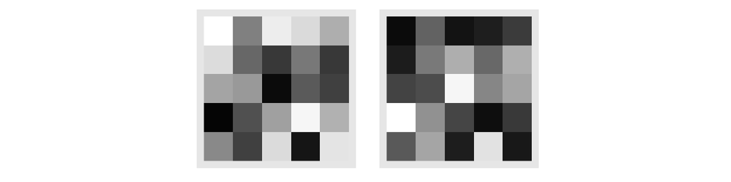

### Example 2

```r
library(rraysplot)
y_segmentation <- array(data = 0, dim = c(1, 6, 6))
y_segmentation[1, 2, 2:4] <- 2
y_segmentation[1, 2:4, 2] <- 2
y_segmentation[1, 3:4, 3:4] <- 1
y_segmentation[1, 5, 3:5] <- 3
y_segmentation[1, 3:5, 5] <- 3
```

```r
y_segmentation[1,,]
```

```
#>      [,1] [,2] [,3] [,4] [,5] [,6]
#> [1,]    0    0    0    0    0    0
#> [2,]    0    2    2    2    0    0
#> [3,]    0    2    1    1    3    0
#> [4,]    0    2    1    1    3    0
#> [5,]    0    0    3    3    3    0
#> [6,]    0    0    0    0    0    0
```

```r
y_encoded <- encodeUnet(y_segmentation, c(0, 1, 2, 3))
y_encoded[1,,,1]
```

```
#>      [,1] [,2] [,3] [,4] [,5] [,6]
#> [1,]    1    1    1    1    1    1
#> [2,]    1    0    0    0    1    1
#> [3,]    1    0    0    0    0    1
#> [4,]    1    0    0    0    0    1
#> [5,]    1    1    0    0    0    1
#> [6,]    1    1    1    1    1    1
```

```r
y_encoded[1,,,2]
```

```
#>      [,1] [,2] [,3] [,4] [,5] [,6]
#> [1,]    0    0    0    0    0    0
#> [2,]    0    0    0    0    0    0
#> [3,]    0    0    1    1    0    0
#> [4,]    0    0    1    1    0    0
#> [5,]    0    0    0    0    0    0
#> [6,]    0    0    0    0    0    0
```

```r
y_encoded[1,,,3]
```

```
#>      [,1] [,2] [,3] [,4] [,5] [,6]
#> [1,]    0    0    0    0    0    0
#> [2,]    0    1    1    1    0    0
#> [3,]    0    1    0    0    0    0
#> [4,]    0    1    0    0    0    0
#> [5,]    0    0    0    0    0    0
#> [6,]    0    0    0    0    0    0
```

```r
y_encoded[1,,,4]
```

```
#>      [,1] [,2] [,3] [,4] [,5] [,6]
#> [1,]    0    0    0    0    0    0
#> [2,]    0    0    0    0    0    0
#> [3,]    0    0    0    0    1    0
#> [4,]    0    0    0    0    1    0
#> [5,]    0    0    1    1    1    0
#> [6,]    0    0    0    0    0    0
```

```r
y_decoded <- decodeUnet(y_encoded, y_encoded[1,,,1])
```

Enoded array and Decoded channels (from 2nd to 4th).

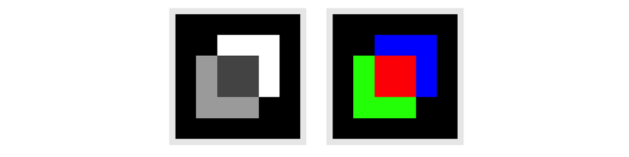

```r
e2 <- plot_array2d(y_segmentation[1,,])
d3 <- plotColor(y_decoded[[1]][2:4])
```